# ncgawron_homework4

Nicholas Gawron, collab: Jamie Loring

3/30/2021

Here we set up our global options. Note that `fig_width` and hieght are included in the global options.

## Graphs of Bank data

0. Read in data with the tidyverse. `bank` is a tibble and the head is shown.

```
## # A tibble: 6 x 21
##     age job    marital education default housing loan  contact month day_of_week
##   <dbl> <chr>  <chr>   <chr>     <chr>   <chr>   <chr> <chr>   <chr> <chr>
## 1    56 house~ married basic.4y  no      no      no    teleph~ may   mon
## 2    57 servi~ married high.sch~ unknown no      no    teleph~ may   mon
## 3    37 servi~ married high.sch~ no      yes     no    teleph~ may   mon
## 4    40 admin. married basic.6y  no      no      no    teleph~ may   mon
## 5    56 servi~ married high.sch~ no      no      yes   teleph~ may   mon
## 6    45 servi~ married basic.9y  unknown no      no    teleph~ may   mon
## # ... with 11 more variables: duration <dbl>, campaign <dbl>, pdays <dbl>,
## #   previous <dbl>, poutcome <chr>, emp.var.rate <dbl>, cons.price.idx <dbl>,
## #   cons.conf.idx <dbl>, euribor3m <dbl>, nr.employed <dbl>, y <chr>
```

## Plots in Base R

1. An attempt at a histogram. This uses the `hist` command and plots our numeric variable of age. We add our kernel line through the `lines` command by passing the `density()` function inside of it. This plots a count of all of the ages of members in our data set. We can observe that our data has a mean age given of around 40.

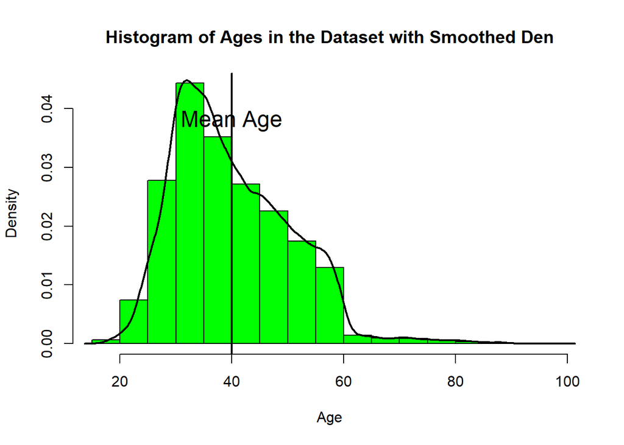

```r
hist(bank$age, main = "Histogram of Ages in the Dataset with Smoothed Den", xlab = "Age", , col = "green",freq = FALSE)
lines(density(bank$age),lwd =2)
abline(v=mean(bank$age),lwd =2, lty =1)
text(x=mean(bank$age), y =0.038, labels = "Mean Age",cex=1.5)
```

```r
#places text "mean age" at the x value of the mean and around the height of 0.04
```

2. Duration Scatter Plot. Here we create a scatter plot in which a persons age is the independent variable on the x-axis and our numeric variable duration is the dependent variable on the y-axis. We group by the variable marital status. We can observe a somewhat obvious trend in our data - that younger people tend to be single. This is evident by the fact we see a lot of green on the left where the ages are a lot lower.

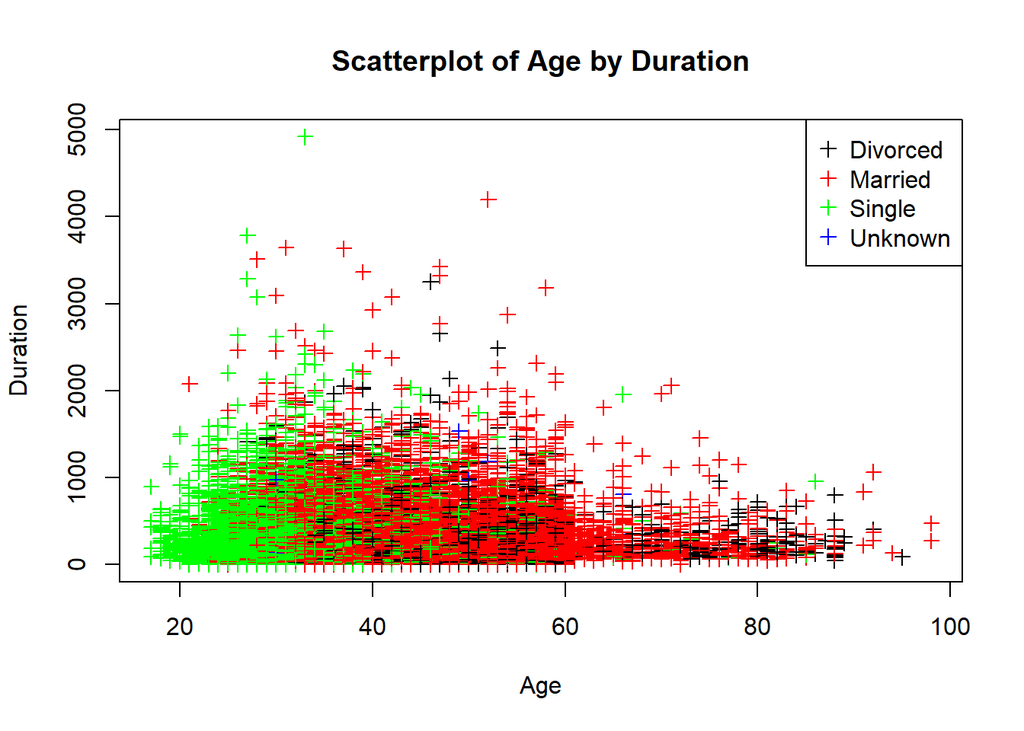

```r
plot(x= bank$age,y=bank$duration, main = "Scatterplot of Age by Duration", pch = 3,xlab = "Age", ylab="Duration", col= c("black","red","green","blue")[as.factor(bank$marital)]) # groups color by a factor of marital, as .factor makes marriage a factor variable

legend("topright", legend = c("Divorced", "Married","Single","Unknown"), pch = 3,col = c("black","red","green","blue"))
```

3. Barplot of Martial Status and Poutcome. Here our x-axis considers the counts of the variable `Poutcome`. This variable measures outcome of the previous marketing campaign per data point (categorical: ‘failure’,‘nonexistent’,‘success’). We then block off and color side by side bars by our martial status variable. We notice that most successful campaigns come from data points that are married.

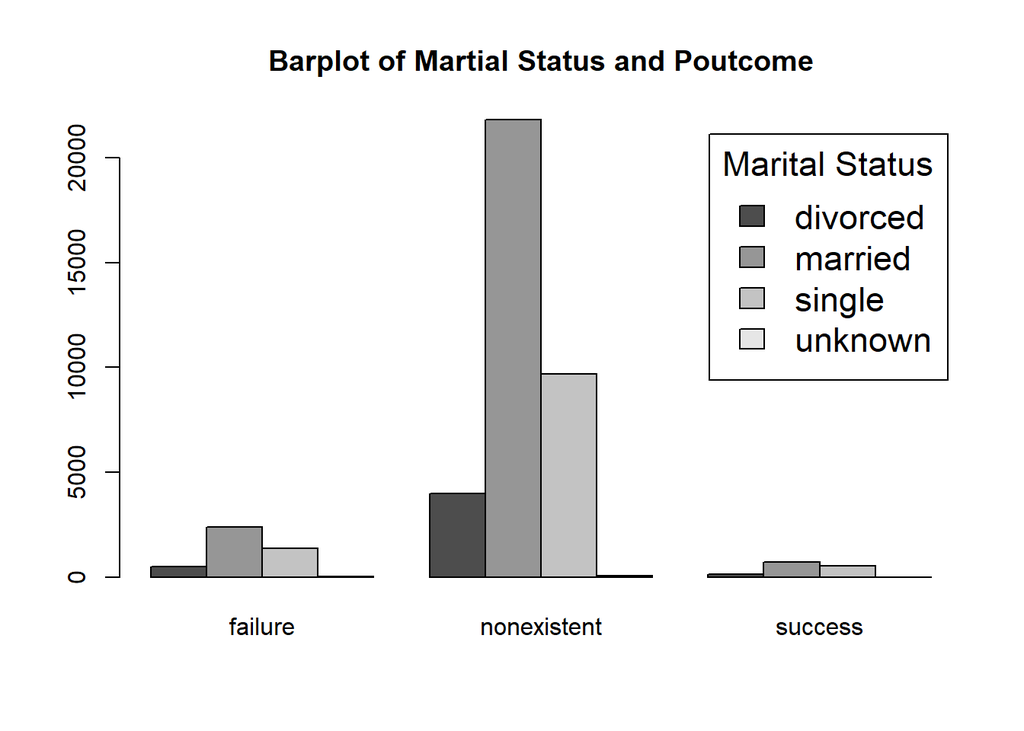

```r
tab1<- table(bank$marital,bank$poutcome)
barplot(tab1, main = "Barplot of Martial Status and Poutcome",beside = TRUE,legend =TRUE, args.legend = list(title = "Marital Status", cex = 1.4))
```

```r
# increases legend size
```

4. We now create a horizatonal boxplot. We will use the same code as the previous question, but must add the `horiz = TRUE` option into our barplot statement. We are still measuring the counts of the poutcome variable and blocking under marital status. We also note that a nonexistent campaign outcome is the greatest count across all **known** marital statuses.

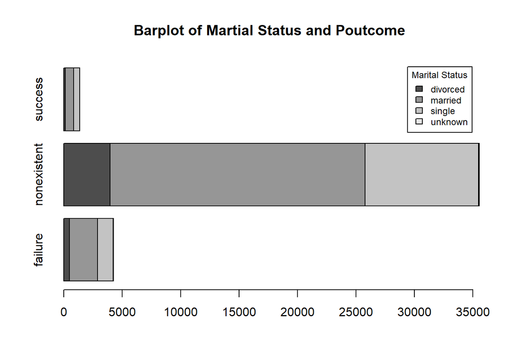

```r
barplot(tab1, main = "Barplot of Martial Status and Poutcome",horiz=TRUE, legend =TRUE, args.legend = list(title = "Marital Status", cex = .75))
```

```r
# agrs legend creates a legend titled and shrunk by 3/4 factor
# horiz = true flips axis
```

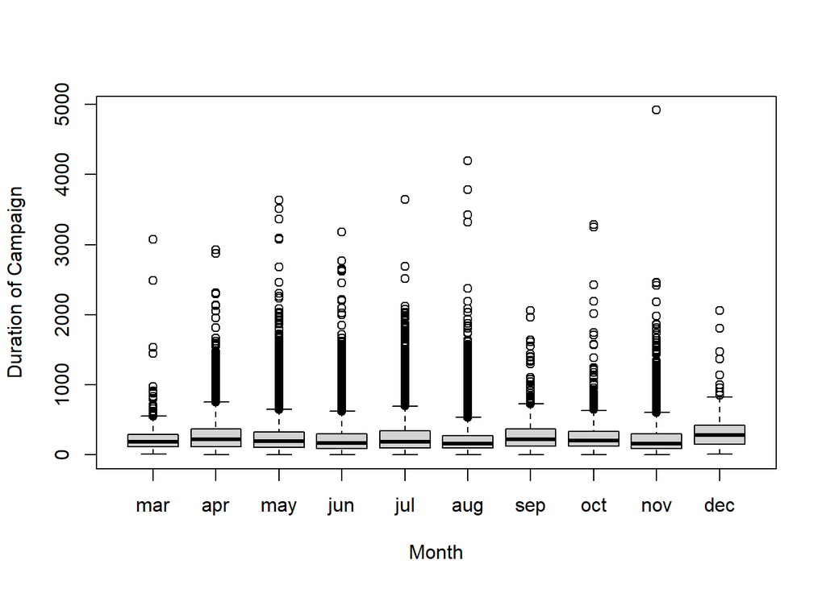

```r
newMth<-factor(bank$month,levels = c("mar","apr","may","jun","jul","aug","sep","oct","nov","dec"))
#reorders the months as a new factor in time order

boxplot(bank$duration~newMth, xlab="Month", ylab="Duration of Campaign" )
```

## Plots if GGplot2

1. Here was have a histogram of the ages of all members in our dataset. This creates a count of the all ages of members in our data sets. We also plot our density curve, which has an area of 1. We can observe a right skew in our data that is quite representative of the real world population. This is because we would have a lot less people over the ages of say 90 than under the age of 50.

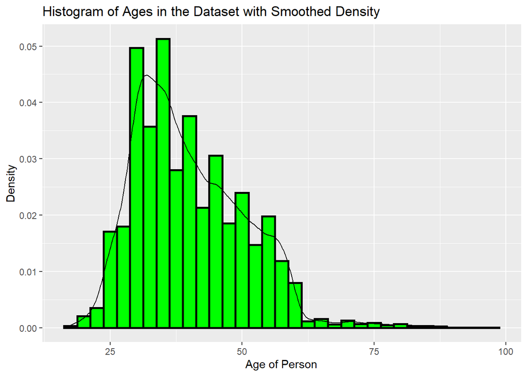

```r
q1 <- ggplot(data = bank, aes(x = age))

q1+geom_histogram(aes(y=..density..,x = age), colour = "black",fill ="green", size = 1, binwidth = 2.5)+geom_density(aes(x=age),kernel = "gaussian")+labs(x ="Age of Person", y="Density",title="Histogram of Ages in the Dataset with Smoothed Density")
```

```r
# gaussian kernel created
```

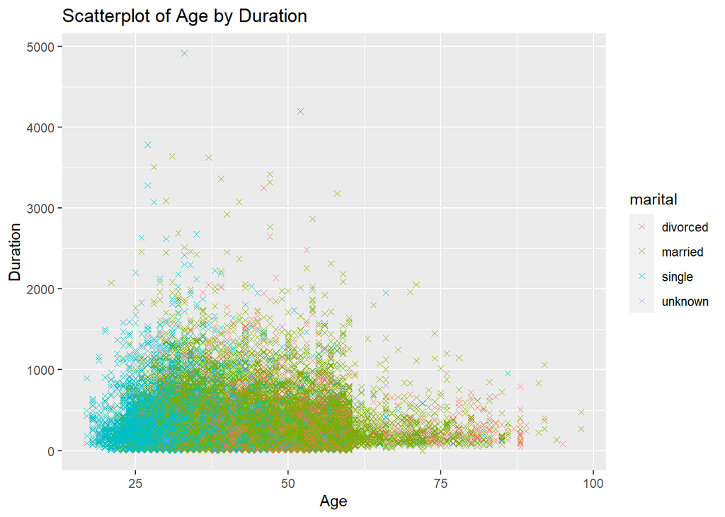

```r
sc<- ggplot(data = bank, aes(x =age, y= duration))
scMarried <- sc+geom_point(pch=4,aes(col=marital))+labs(x="Age", y= "Duration",title="Scatterplot of Age by Duration")
scMarried # stores general plot as scMarried
```

```r
#geom_point creates scatter plot and groups by martial variable
```

3. We consider the same plot above. We are plotting the ages of persons on the x axis, and the duration of the campiagn on the y axis. We then group by tow different variables like martical status and campaign outcome. In general successful calls seemed to have overall smaller / shorter duration of campaign length.

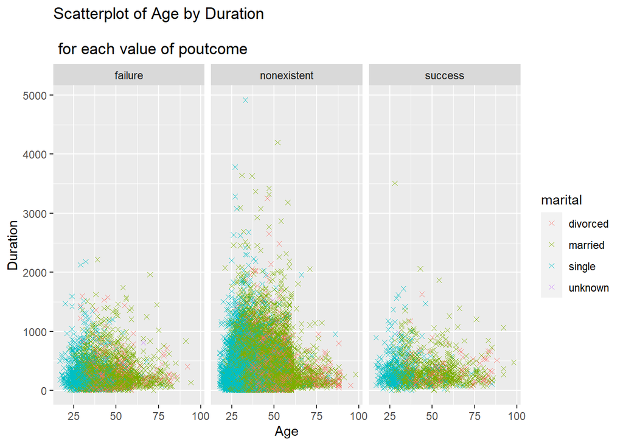

```r
scMarried+facet_wrap(~poutcome)+labs(title="Scatterplot of Age by Duration \n
 for each value of poutcome")# groups by our variable poutcome
```

4. Barplot of Martial Status and Poutcome. Here we use `ggplot()` to create a graphing instance and a bar plot that measures the count of data points that had a certain marital status. We then group these counts by the variable of campoagn outcome `poutcome`. We notice that married members in our data set had greater raw success by count.

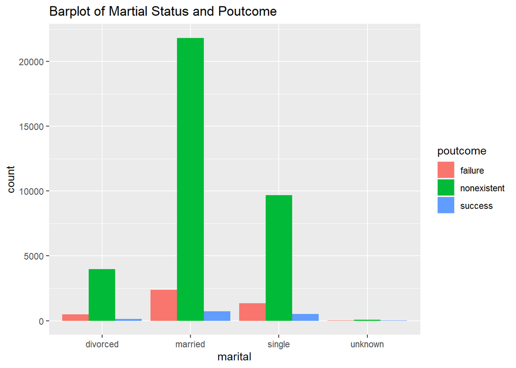

```r
BarGG<- ggplot(data=bank, aes(x=marital, fill =poutcome)) #creates x variable
BarrGGvert<-BarGG+geom_bar(position = "dodge")+labs(title="Barplot of Martial Status and Poutcome")
BarrGGvert
```

5. This creates a flipped barchart. In question 4, we store our vertical bar chart, along with the ggplot instance as `BarrGGvert`. By using this instance, we thne have the complete figure stored in one term. We then add a simple layer, `coord_flip()` to this variable. This results in a transpose of our axis and plotting. We notice that across all forms of martial status - success was the least likely outcome for a data point.

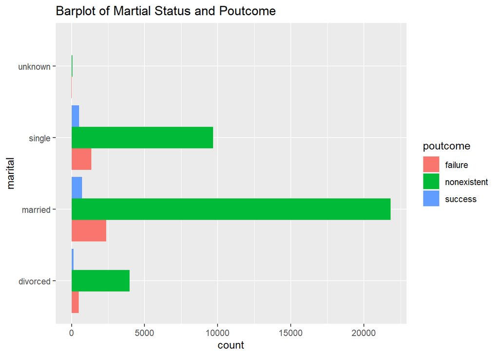

```r
BarrGGvert+coord_flip()# flips axis
```

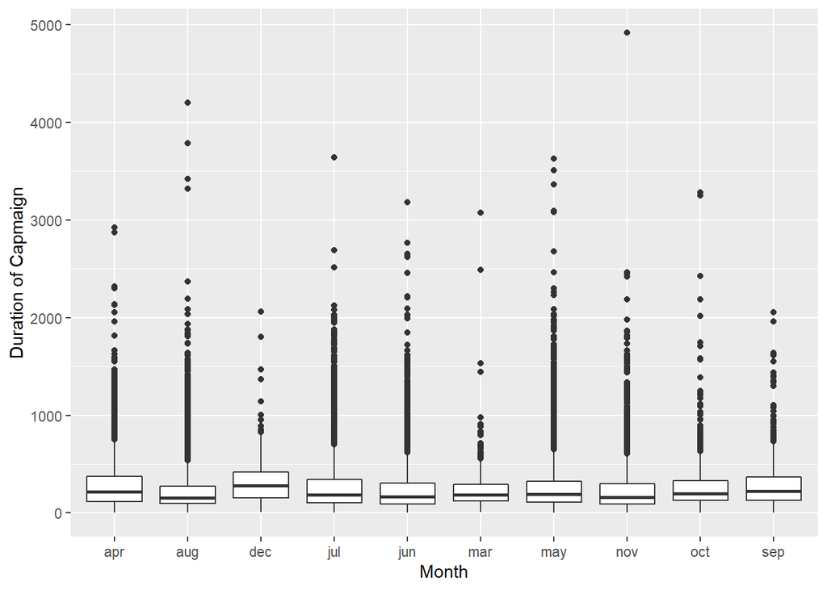

```r
BoxGG<- ggplot(data=bank,aes(x=month, y =duration)) #makes ggplot isntance
BoxGG + geom_boxplot(fill="white")+labs(y="Duration of Capmaign",x="Month") # labels
```